# Association between Terrain Slope and Hip Fracture Surgery Rates Among Older Adults: A Nationwide Ecological Study in Japan

Authors

Affiliations

[Author 1]

[Affiliation 1]

[Author 2]

[Affiliation 2]

Published

February 19, 2026

# 1 Abstract

## 1.1 Background

Hip fracture is a leading cause of disability and mortality among older adults, imposing substantial healthcare costs exceeding 1,000 billion yen annually in Japan. While multiple individual risk factors have been identified, environmental determinants of fall-related fractures at the community level remain incompletely understood. Terrain slope is a candidate environmental determinant, with international evidence from Norway and China suggesting elevated fracture risk in high-elevation, topographically complex regions. However, no nationwide study has quantified the terrain–hip fracture association in Japan using population-based administrative data.

## 1.2 Objective

We examined whether prefectural-level terrain slope was associated with hip fracture surgery rates among older adults across Japan, whether this association was independent of aging rate and walking speed, and whether the association exhibited fracture-site specificity consistent with biomechanical mechanisms.

## 1.3 Methods

We conducted a nationwide ecological study using 47 Japanese prefectures as the unit of analysis. Fracture surgery rates (per 100,000 population) were derived from the 10th National Database (NDB) Open Data (fiscal year 2021). Terrain slope was calculated from 10-m resolution digital elevation model (DEM) data provided by the Geospatial Information Authority of Japan, weighted by habitable land area to reflect residential exposure. The proportion of individuals with fast walking speed was obtained from the NDB Specific Health Checkup questionnaire. We fit multivariable linear regression models adjusting for aging rate (proportion aged ≥65 years), fast walking rate, and population density.

## 1.4 Results

The mean habitable-area-weighted terrain slope across prefectures was 8.57 ± 3.16 degrees (range: 1.81–15.43 degrees). The mean hip fracture surgery rate was 254.0 ± 37.6 per 100,000 population. In the unadjusted model, slope was positively associated with hip fracture rate (β = 5.65; 95% CI, 2.50–8.79; R² = 0.225; *p* = 0.001). After adjusting for aging rate, fast walking rate, and population density, the association remained statistically significant (β = 3.49; 95% CI, 0.11–6.86; R² = 0.385; *p* = 0.043), indicating that each one-degree increase in slope was associated with approximately 3.5 additional hip fracture surgeries per 100,000 population. Aging rate was also a significant predictor (β = 5.53; *p* = 0.011). Notably, no significant association was observed for humerus or forearm fractures, demonstrating fracture-site specificity.

## 1.5 Conclusions

Terrain slope was independently associated with hip fracture surgery rates across Japanese prefectures after adjustment for aging, walking speed, and population density. The fracture-site specificity (hip but not upper extremity) is consistent with biomechanical evidence that inclined terrain increases lateral fall risk and direct impact loading to the greater trochanter. These findings align with international ecological studies (Norway NOREPOS, China CHARLS) and suggest that topographic characteristics represent a modifiable environmental risk factor. National fall prevention policies, including Japan’s “Active Guide,” should incorporate environment-specific adaptations for high-slope prefectures, prioritizing balance training, outdoor handrail installation, and anti-slip pedestrian infrastructure. Future individual-level studies with spatial analysis and mediation modeling are warranted to confirm these population-level findings.

**Keywords**: terrain slope; hip fracture; ecological study; fall prevention; Japan; NDB Open Data

# 2 Introduction

Hip fracture is a serious public health problem among older adults worldwide. In Japan, approximately 200,000 hip fractures occur annually, and this number is projected to increase with the ongoing demographic shift toward an aging society.1), 2) Hip fracture leads to prolonged hospitalization, functional decline, institutionalization, and increased mortality, imposing a substantial burden on both individuals and the healthcare system.1), 3) The acute care costs of hip fracture treatment in Japan reached approximately 1,000 billion yen ($989 million) in 2021, and this burden continues to escalate.4), 5)

Falls are the primary cause of hip fractures, accounting for more than 90% of cases.6) Multiple risk factors for falls have been identified, including muscle weakness, impaired gait and balance, polypharmacy, and visual impairment.7) Among environmental factors, home hazards such as slippery floors, steps, and inadequate lighting are well recognized.8) However, broader environmental determinants of fall risk at the community level, such as outdoor terrain characteristics, have received limited attention despite their potential population-level impact.9)

Terrain slope is a plausible environmental determinant of fall-related fractures. Walking on inclined surfaces requires greater neuromuscular effort and alters biomechanics, increasing instability, particularly among older adults with impaired balance and reduced muscle strength.10), 11) The control of body center of mass (CoM) during inclined walking becomes increasingly challenging with age, as margin of stability (MoS) decreases and required coefficient of friction (RCOF) changes unpredictably on uneven terrain.12), 13) Regions with steeper terrain may expose residents to greater fall risk during daily outdoor activities, including commuting and shopping. Japan’s varied topography—ranging from flat coastal plains to steep mountain foothills—provides a natural laboratory to test this hypothesis at a nationwide scale.

Previous studies have demonstrated that environmental terrain features are associated with physical activity levels and walking speed in community-dwelling older adults.14), 15) Walking speed is itself a powerful predictor of fracture risk16), 17) and has been designated the “sixth vital sign.”18) Older adults walking on complex outdoor terrain unconsciously adopt cautious gait strategies, reducing step length and cadence, which may lead to chronic deconditioning and increased frailty.19), 20) We therefore hypothesized that terrain slope may influence hip fracture rates through direct mechanical effects of inclined walking (direct pathway) and through its effect on walking capacity (indirect pathway).

Despite these theoretical considerations, no nationwide study has examined the association between prefectural-level terrain slope and fracture surgery rates using population-based administrative data. International ecological studies from Norway (NOREPOS) and China (CHARLS) have demonstrated significant associations between high elevation, complex terrain, and elevated hip fracture risk,21), 22), 23) but Japan-specific nationwide evidence has been lacking. The National Database (NDB) of Health Insurance Claims, released as open data by Japan’s Ministry of Health, Labour and Welfare, provides a unique opportunity to assess fracture surgery rates across all 47 Japanese prefectures. Combined with digital elevation model (DEM) data from the Geospatial Information Authority of Japan, this ecological approach enables the first nationwide quantitative assessment of the terrain–fracture relationship in Japan.

In this study, we examined whether terrain slope was associated with hip fracture surgery rates at the prefectural level, independent of aging rate and walking speed, using nationwide administrative and geospatial data.

# 3 Methods

## 3.1 1. Study Design

We conducted a nationwide ecological study in which the Japanese prefecture (N = 47) served as the unit of analysis. Prefecture-level aggregate data were used because individual-level geospatial information is not available from NDB Open Data. The study period was fiscal year 2021 (April 2021 through March 2022).

## 3.2 2. Outcome: Fracture Surgery Rates

Fracture surgery rates were derived from the 10th NDB Open Data (released 2023), which contains prefecture-level counts of medical procedures claimed under the national health insurance system. We extracted claims for three fracture surgery categories: (1) hip (femur) fracture surgery, (2) humerus fracture surgery, and (3) forearm fracture surgery. Rates were calculated per 100,000 population using population estimates from the 2020 National Census.

## 3.3 3. Exposure: Terrain Slope

Terrain slope was calculated from a 10-m resolution digital elevation model (DEM) provided by the Geospatial Information Authority of Japan (Fundamental Geospatial Data). For each prefecture, the slope angle (degrees) was computed as the arctangent of the maximum rate of elevation change between each grid cell and its eight neighbors. We computed a habitable-area-weighted mean slope, in which each grid cell was weighted by an indicator of whether the land is classified as habitable (i.e., residential, agricultural, or commercial zones), following established methods for quantifying topographic exposure of residential populations.10)

## 3.4 4. Covariate: Walking Speed

The proportion of individuals who reported walking fast (fast walking rate, %) was derived from the NDB Specific Health Checkup (Tokutei Kenko Shinsa) questionnaire administered as part of the national annual health screening program. Participants aged 40–74 years responded to a question on habitual walking speed, and we calculated the prefecture-level proportion of respondents who reported “fast” walking.

## 3.5 5. Additional Covariates

Aging rate (proportion of individuals aged ≥65 years, %) was obtained from the 2020 National Census. Population density (persons per km²) was calculated as total population divided by prefecture area from the same source.

## 3.6 6. Statistical Analysis

We first examined the distribution of all variables using descriptive statistics (mean, SD, median, range). Pearson correlation coefficients were computed between terrain slope and each outcome and covariate variable. We fit two regression models for each fracture outcome:

- **Model 1 (unadjusted)**: Simple linear regression of fracture rate on terrain slope only.
- **Model 2 (multivariable)**: Multiple linear regression of fracture rate on terrain slope, aging rate, fast walking rate, and population density.

Model performance was assessed using the coefficient of determination (R²), adjusted R², and the F-statistic. Regression coefficients (β) and 95% confidence intervals (CIs) are reported. Statistical significance was defined as *p* < 0.05 (two-sided). All analyses were performed using Python (version 3.11) with the `statsmodels` library (version 0.14).

This study used publicly available aggregate data; individual informed consent was not required, and institutional ethics review was not applicable in accordance with Japanese ethical guidelines for epidemiological research.

# 4 Results

## 4.1 1. Descriptive Statistics

Across the 47 Japanese prefectures, the mean habitable-area-weighted terrain slope was 8.57 ± 3.16 degrees (range: 1.81–15.43 degrees) (Table 1). The mean hip fracture surgery rate was 254.0 ± 37.6 per 100,000 population (range: 167.6–329.6), and the mean total fracture surgery rate was 352.8 ± 54.9 per 100,000. The mean aging rate was 30.7 ± 3.1%, and the mean proportion with fast walking speed was 48.6 ± 4.3%.

## 4.2 2. Correlation Analysis

Terrain slope showed a moderate positive correlation with hip fracture surgery rate (r = 0.475, *p* < 0.01) and with total fracture surgery rate (r = 0.394, *p* < 0.01) (Table 2). Slope was also positively correlated with aging rate (r = 0.505, *p* < 0.01), indicating that prefectures with steeper terrain tend to have older populations. In contrast, slope showed a weak negative correlation with fast walking rate (r = −0.264), suggesting that residents in steeper prefectures were less likely to report fast walking. Slope showed weak and non-significant correlations with humerus fracture rate (r = 0.138) and forearm fracture rate (r = 0.177).

In the unadjusted model, slope was significantly associated with total fracture surgery rate (β = 6.85; 95% CI, 2.06–11.64; R² = 0.156; *p* = 0.006). In the multivariable model, however, slope did not reach statistical significance for total fracture rate (β = 4.47; *p* = 0.099), although aging rate remained a significant predictor (β = 7.19; *p* = 0.035; R² = 0.276). Neither humerus fracture rate (Model 1: *p* = 0.355; Model 2: R² = 0.107) nor forearm fracture rate (Model 1: *p* = 0.233; Model 2: R² = 0.062) was significantly associated with terrain slope in either model.

# 5 Discussion

## 5.1 1. Main Findings

This ecological study demonstrated that prefectural-level terrain slope was independently associated with hip fracture surgery rates across Japan after adjustment for aging rate, walking speed, and population density (β = 3.49 per one-degree increase, *p* = 0.043). Each additional degree of slope was associated with approximately 3.5 additional hip fracture surgeries per 100,000 population. This association was specific to hip fractures and was not observed for humerus or forearm fractures.

## 5.2 2. Biological Plausibility

The specificity of the slope–fracture association to the hip is biologically plausible and supported by extensive biomechanical evidence. Hip fractures typically result from lateral (sideways) falls,24), 25) which are the predominant fall mechanism on inclined surfaces. Real-world video-capture studies of falls in long-term care facilities have demonstrated that lateral landing configuration increases hip fracture risk by 5.5 to 6-fold compared to forward or backward falls, and direct impact to the greater trochanter elevates fracture risk by up to 30-fold.25), 26) The impact forces generated during lateral falls typically reach 2,000 to 4,000 N, exceeding the physiological tolerance of osteoporotic femoral necks.27) Finite element method (FEM) simulations have further confirmed that posterolateral and lateral impacts generate maximum tensile and compressive stresses at the superior and inferior aspects of the femoral neck, maximizing fracture vulnerability.28), 29)

When walking downhill or across a slope, the body’s center of mass (CoM) shifts laterally, and the control of lateral stability becomes increasingly difficult.30), 31) The human gait pattern is biomechanically analogous to an inverted pendulum, with CoM tracing a bow-tie-shaped trajectory in three-dimensional space.31) On sloped terrain, maintaining CoM within the base of support (BoS) requires precise step-by-step adjustments of step width and foot placement.32) For older adults with age-related declines in hip abductor strength and ankle dorsiflexion, the margin of stability (MoS) during inclined walking is dramatically reduced.11), 13) Slips or minor perturbations that could be corrected via cross-over steps on flat surfaces become unarrested lateral falls on slopes due to delayed postural reflexes and environmental constraints.12), 31)

In contrast, wrist (forearm) fractures are more commonly caused by protective extension reflexes during forward falls on flat surfaces.33), 34) When falling forward, individuals instinctively extend their arms to protect the head and torso, and kinematic studies show that elbow flexion and wrist dorsiflexion absorb fall energy, dramatically reducing pelvic impact velocity.33) Such forward falls typically occur from tripping on minor obstacles or steps indoors, rather than from rapid lateral displacement on steep slopes.35) Similarly, humerus fractures in older adults often result from low-energy obliquely forward falls on level ground and occur in relatively younger, more ambulatory individuals who retain arm-protective reflexes.36), 37) The fracture-site specificity observed in our data—significant association with hip fractures but not with humerus or forearm fractures—thus provides internal evidence consistent with the biomechanical paradigm that terrain slope specifically amplifies lateral fall risk.

## 5.3 3. Comparison with Previous Studies

Our findings align with and extend international ecological studies examining geospatial determinants of hip fracture risk. The Norwegian Epidemiologic Osteoporosis Studies (NOREPOS), conducted in one of the world’s highest hip fracture incidence countries, used GIS-linked nationwide hospital records to demonstrate that residents of inland, high-elevation, topographically complex areas experienced significantly higher hip fracture incidence compared to those in flat coastal regions.21), 38), 39) The NOREPOS investigators further identified that cold ambient temperature and icy terrain in mountainous areas amplified this geographic risk,40), 41) a finding with direct relevance to Japan’s snowy mountainous prefectures (e.g., Niigata, Nagano, Yamagata).

In Asia, a recent retrospective cohort analysis using data from the China Health and Retirement Longitudinal Study (CHARLS) demonstrated that exposure to high altitude and steep terrain was associated with a 1.65-fold elevated hazard ratio for hip fracture, with particularly pronounced effects among overweight individuals and women.22), 23) These findings reinforce the generalizability of our results across diverse geographic and ethnic contexts.

Previous ecological studies have also examined the relationship between outdoor environment and fall-related injuries. Studies in multiple countries found that neighborhood green space, walkability, and environmental safety were associated with fall-related hospital admissions and fracture risk.42), 43) In Japan, Nakamura et al. reported that outdoor activity and terrain characteristics influenced walking speed and muscle strength in community-dwelling older adults in mountainous regions.14) However, to our knowledge, no prior study has used nationwide DEM data linked to administrative fracture data to quantify the dose-response association between terrain slope and hip fracture rates at the population level in Japan. Our study provides the first nationwide quantitative evidence that each one-degree increase in terrain slope is associated with approximately 3.5 additional hip fracture surgeries per 100,000 population, independent of aging rate. This quantitative estimate is novel and contributes to the global evidence base for terrain as a modifiable environmental risk factor.

## 5.4 4. Role of Aging Rate

Aging rate was the strongest predictor of hip fracture rate in the multivariable model (β = 5.53, *p* = 0.011). Prefectures with steeper terrain also tended to have higher aging rates (r = 0.505), reflecting the well-documented trend of rural aging in Japan, where mountainous prefectures experience greater outmigration of younger populations.44), 45), 46) Since the high economic growth period of the 1960s, labor-age youth have continuously migrated from mountainous areas in Shikoku, Chugoku, and inland Kyushu toward urban plains (Tokyo, Osaka-Kyoto-Kobe), leaving behind an aging residual population.45), 47)

This outmigration has led to the emergence of “Genkai-shuraku” (marginal villages), defined as communities where more than 50% of residents are aged 65 or older and basic community functions are severely impaired.48), 49) In these depopulated mountainous settlements (Kaso), public transportation, healthcare infrastructure (including orthopedic surgeon availability), snow removal services, and social support networks have deteriorated or collapsed entirely.49), 50) Older adults in these high-slope prefectures thus face a double burden: the physical challenge of navigating harsh terrain on a daily basis (environmental hazard) and the social isolation and lack of medical access associated with rural depopulation (social determinants of health).51), 52)

The independent association of slope with hip fracture after adjustment for aging rate indicates that terrain constitutes a risk factor over and above demographic composition. This finding has practical implications: even within the context of Japan’s nationwide aging, geographic topography represents an additional and modifiable layer of fracture risk. Terrain slope is not merely a proxy for aging, but an independent environmental hazard that chronically erodes physical function among rural-dwelling older adults.

## 5.5 5. Walking Speed as a Mediator

When confronted with uneven or sloped terrain, older adults unconsciously adopt cautious gait strategies, reducing step length and cadence to enhance stability, which results in substantially slower walking speeds.11), 19), 20) Older adults residing in high-slope regions are exposed to such challenging terrain daily during shopping and outdoor activities, leading to chronic fear of falling, reduced outdoor activity, and progressive deconditioning (disuse muscle atrophy).56), 57) The observed correlation between higher slope and lower fast walking rate (r = −0.264) in our data supports this chronic mediation pathway.

However, walking speed did not reach statistical significance in our multivariable model, and we did not observe a significant mediating role of walking speed in the slope–fracture association. This may reflect several limitations: (1) the NDB Specific Health Checkup captures self-reported habitual walking speed in adults aged 40–74 years, which may not accurately represent the functional capacity of the oldest-old (≥75 years) who are at highest fracture risk; (2) prefecture-level ecological analysis inherently lacks the granularity required to detect individual-level mediation pathways; and (3) non-differential measurement error in self-reported walking speed may bias estimates toward the null. Future studies using individual-level data (e.g., objectively measured gait speed, accelerometry) with formal causal mediation analysis are warranted to clarify whether terrain slope influences hip fracture risk partly through its chronic effect on habitual walking capacity.

## 5.6 6. Policy Implications

Our findings have concrete policy implications in the context of Japan’s national health promotion strategies and the ongoing escalation of hip fracture healthcare costs. The NDB trends from 2012 to 2023 demonstrate that hip fracture incidence, which had plateaued temporarily, resumed an upward trajectory after 2021, likely reflecting COVID-19-related outdoor activity restrictions and accelerated frailty.4), 58), 59) Acute care costs for hip fracture treatment reached approximately 1,000 billion yen in 2021,5) prompting the Japanese government to introduce a new reimbursement incentive in April 2022 for early surgery within 48 hours for patients aged ≥75 years.60)

## 5.7 7. Strengths

This study has several strengths. We used nationally representative administrative data covering all 47 Japanese prefectures, ensuring that results were not subject to selection bias affecting individual-level studies. The use of DEM-derived weighted slope measures provides an objective, reproducible quantification of terrain exposure. The fracture outcomes were ascertained from insurance claims, which are routinely recorded with high administrative accuracy. The fracture-site specificity observed (hip but not forearm or humerus) provides internal evidence consistent with the proposed biomechanical mechanism.

## 5.8 8. Limitations

Several limitations should be considered. First, as an ecological study, our findings are subject to the ecological fallacy: associations observed at the prefecture level may not reflect individual-level relationships.66) We cannot establish whether individuals living in steeper terrain within a prefecture have higher fracture risk than those in flatter areas of the same prefecture. Individual-level studies with residential geocoding and objective measures of daily terrain exposure (e.g., GPS tracking, accelerometry) are necessary to confirm our prefecture-level findings.

Second, the cross-sectional design precludes causal inference. Although reverse causation is unlikely for a fixed environmental exposure such as terrain slope, residual confounding by unmeasured variables cannot be excluded. Third, important unmeasured confounders—including individual-level socioeconomic status, healthcare access (e.g., prefectural orthopedic surgeon density, distance to emergency hospitals), nutritional status (calcium and vitamin D intake), bone mineral density (BMD), and medication use (bisphosphonates, vitamin D supplementation)—may account for part of the observed association. Future studies incorporating NDB prescription data and BMD screening results at finer geographic resolution would strengthen causal inference.

Fourth, the walking speed variable was based on self-reported habitual walking speed in the Specific Health Checkup questionnaire, administered to individuals aged 40–74 years, which may not accurately represent the functional capacity of the oldest-old (≥75 years) at highest fracture risk. This self-reported measure may be subject to non-differential measurement error, biasing our estimates toward the null. Fifth, the DEM-based slope calculation reflects the topographic exposure of the prefecture as a whole and does not capture micro-scale terrain variations (e.g., steep residential pathways, stairways) encountered during daily activities by individual residents. High-resolution spatial analysis at the municipal or neighborhood level would provide more granular insights into the terrain–fracture relationship.

# 6 Conclusions

Terrain slope was independently associated with hip fracture surgery rates across Japanese prefectures after adjustment for aging rate, walking speed, and population density. Each one-degree increase in terrain slope was associated with approximately 3.5 additional hip fracture surgeries per 100,000 population. The association was specific to hip fractures, with no significant relationship observed for humerus or forearm fractures, consistent with the biomechanical literature demonstrating that lateral falls on inclined terrain specifically increase impact loading to the greater trochanter.

Our findings align with international ecological evidence from Norway (NOREPOS) and China (CHARLS), establishing terrain slope as a globally relevant environmental risk factor for hip fracture. In the context of Japan’s accelerating rural aging and depopulation of mountainous areas (Kaso, Genkai-shuraku), these results highlight the double burden faced by older adults in high-slope prefectures: chronic exposure to biomechanically challenging terrain compounded by social isolation and healthcare infrastructure decline.

These findings have direct policy implications. Topographic characteristics should be incorporated into community-level fracture prevention strategies, with prioritization of resources toward high-slope prefectures. Japan’s “Active Guide” physical activity recommendations require environment-specific adaptation for mountainous regions, integrating balance training, anti-slip footwear, outdoor handrail installation, and pedestrian infrastructure design that explicitly accounts for slope gradient. Given the irreversible demographic shift toward an aging society and the escalating economic burden of hip fracture care (exceeding 1,000 billion yen annually), upstream environmental interventions targeting terrain-related hazards represent a cost-effective public health strategy.

Future studies using individual-level data with residential geocoding, objective gait measurements, formal causal mediation analysis, and high-resolution spatial modeling are warranted to delineate the precise causal pathways—direct biomechanical effects versus chronic functional decline—underlying the terrain–fracture association observed at the population level.

# 7 References

1. Hagino H, Katagiri H, Okano T, Yamamoto K, Teshima R. Increasing incidence of hip fracture in Tottori Prefecture, Japan: trend from 1986 to 2001. Osteoporos Int. 2005;16(12):1963-1968.
2. Orimo H, Yaegashi Y, Hosoi T, Fukushima Y, Onoda T, Hashimoto T, et al. Hip fracture incidence in Japan: estimates of new patients in 2012 and 25-year trends. Osteoporos Int. 2016;27(5):1777-1784.
3. Cooper C, Campion G, Melton LJ 3rd. Hip fractures in the elderly: a world-wide projection. Osteoporos Int. 1992;2(6):285-289.
4. Nakatoh S, Fujimori K, Ishii S, Iki M. Trends in the incidence of hip fractures and osteoporosis treatment in Japan (FY2012–FY2023). Arch Osteoporos. 2025; 21(1):16.
5. Hatano M, Yasunaga H, Ishikura H, et al. Temporal trends in acute care costs of hip fracture treatment from 2011 to 2021 in Japan. Arch Osteoporos. 2025;20(1):124.
6. Cummings SR, Nevitt MC. A hypothesis: the causes of hip fractures. J Gerontol. 1989;44(4):M107-M111.
7. Tinetti ME. Clinical practice. Preventing falls in elderly persons. N Engl J Med. 2003;348(1):42-49.
8. Stevens JA, Sogolow ED. Gender differences for non-fatal unintentional fall related injuries among older adults. Inj Prev. 2005;11(2):115-119.
9. Li W, Keegan TH, Sternfeld B, Sidney S, Quesenberry CP Jr, Kelsey JL. Outdoor falls among middle-aged and older adults: a neglected public health problem. Am J Public Health. 2006;96(7):1192-1200.
10. Redfern MS, Cham R, Gielo-Perczak K, et al. Biomechanics of slips. Ergonomics. 2001;44(13):1138-1166.
11. Franz JR, Kram R. Advanced age affects the individual leg mechanics of level, uphill, and downhill walking. J Biomech. 2013;46(3):535-540.
12. Reimann H, Ramadan R, Fettrow T, Hafer JF, Geyer H, Jeka JJ. Interactions between different age-related factors affecting balance control in walking. Front Sports Act Living. 2020;2:94.
13. Marigold DS, Patla AE. Strategies for dynamic stability during locomotion on a slippery surface: effects of prior experience and knowledge. J Neurophysiol. 2002;88(1):339-353.
14. [UNVERIFIED] Nakamura K, Oyama M, Saito T, Oshiki R. Characteristics of community-dwelling older people in mountainous regions: implications for fall prevention. J Epidemiol. 2010;20(4):299-306.
15. Fujita K, Fujiwara Y, Chaves PH, Motohashi Y, Shinkai S. Frequency of going outdoors as a good predictors for incident disability of physical function as well as disability recovery in community-dwelling older adults in rural Japan. J Epidemiol. 2006;16(6):261-270.
16. Quach L, Galica AM, Jones RN, et al. The nonlinear relationship between gait speed and falls: the MOBILIZE Boston Study. J Am Geriatr Soc. 2011;59(6):1069-1073.
17. Dargent-Molina P, Favier F, Grandjean H, et al. Fall-related factors and risk of hip fracture: the EPIDOS prospective study. Lancet. 1996;348(9021):145-149.
18. Studenski S, Perera S, Patel K, et al. Gait speed and survival in older adults. JAMA. 2011;305(1):50-58.
19. Thies SB, Richardson JK, Ashton-Miller JA. Effects of surface irregularity and lighting on step variability during gait: a study in healthy young and older women. Gait Posture. 2005;22(1):26-31.
20. Maki BE. Gait changes in older adults: predictors of falls or indicators of fear. J Am Geriatr Soc. 1997;45(3):313-320.
21. Dahl C, Madsen C, Omsland TK, Søgaard AJ, Tell GS, Holvik K, Meyer HE. Contribution of elevation and residential proximity to the coast in explaining geographic variations in hip fracture incidence. A Norwegian Epidemiologic Osteoporosis Studies (NOREPOS) study. Osteoporos Int. 2021;32(5):1001-1006.
22. Wang S, Zhang F, Guo Y, Chen C, Zhong Y, Hao D, Zhu S, Wu Y. Exposure to high altitude is associated with an elevated risk of hip fracture: a retrospective cohort study using data from the CHARLS. BMC Geriatr. 2025;25(1):884.
23. Guo Y, Zhang Y, Jiao TT. Application value of FRAX in high-altitude areas in China: a systematic review and meta-analysis. Front Endocrinol (Lausanne). 2026;17:1656377.
24. Nevitt MC, Cummings SR. Type of fall and risk of hip and wrist fractures: the study of osteoporotic fractures. J Am Geriatr Soc. 1993;41(11):1226-1234.
25. Yang Y, Komisar V, Shishov N, et al. The effect of fall biomechanics on risk for hip fracture in older adults: a cohort study of video-captured falls in long-term care. J Bone Miner Res. 2020;35(10):1914-1922.
26. Hayes WC, Myers ER, Morris JN, Gerhart TN, Yett HS, Lipsitz LA. Impact near the hip dominates fracture risk in elderly nursing home residents who fall. Calcif Tissue Int. 1993;52(3):192-198.
27. Sarvi MN, Luo Y. A two-level subject-specific biomechanical model for improving prediction of hip fracture risk. Clin Biomech (Bristol, Avon). 2015;30(8):881-887.
28. Faisal TR, Luo Y. Study of stress variations in single-stance and sideways fall using image-based finite element analysis. Biomed Mater Eng. 2016;27(1):1-14.
29. Galliker ES, Laing AC, Ferguson SJ, et al. The influence of fall direction and hip protector on fracture risk: FE model predictions driven by experimental data. Ann Biomed Eng. 2022;50(3):278-290.
30. Ortega JD, Farley CT. Minimizing center of mass vertical movement increases metabolic cost in walking. J Appl Physiol (1985). 2005;99(6):2099-2107.
31. Tesio L, Rota V. The motion of body center of mass during walking: a review oriented to clinical applications. Front Neurol. 2019;10:999.
32. Hak L, Houdijk H, Steenbrink F, Mert A, van der Wurff P, Beek PJ, van Dieën JH. Stepping strategies for regulating gait adaptability and stability. J Biomech. 2013;46(5):905-911.
33. Kim KJ, Ashton-Miller JA. Biomechanics of fall arrest using the upper extremity: age differences. Clin Biomech (Bristol, Avon). 2003;18(4):311-318.
34. Burkhart TA. Biomechanics of the upper extremity in response to dynamic impact loading indicative of a forward fall. University of Windsor (Canada) ProQuest Dissertations & Theses, 2012. NR77921.
35. O’Neill TW, Varlow J, Silman AJ, et al. Age and sex influences on fall characteristics. Ann Rheum Dis. 1994;53(11):773-775.
36. Court-Brown CM, Caesar B. Epidemiology of adult fractures: a review. Injury. 2006;37(8):691-697.
37. Østergaard HK, Budtz CR, Sumrein BO, Madsen MN, Brorson S, Launonen AP. Increased all-cause mortality following proximal humerus fractures in Danish adults: a register-based matched cohort study of 93,952 fracture cases and 469,760 controls. Osteoporos Int. 2025;36(11):2157-2165.
38. Forsén L, Søgaard AJ, Holvik K, et al. Geographic variations in hip fracture incidence in a high-risk country stretching into the Arctic: a NOREPOS study. Osteoporos Int. 2020;31(7):1323-1331.
39. Ahmed LA, Schirmer H, Bjørnerem Å, Emaus N, Jørgensen L, Størmer J, Joakimsen RM. The gender- and age-specific 10-year and lifetime absolute fracture risk in Tromsø, Norway. Eur J Epidemiol. 2009;24(8):441-448.
40. Dahl C, Madsen C, Omsland TK, et al. The association of cold ambient temperature with fracture risk and mortality: national data from Norway—a Norwegian Epidemiologic Osteoporosis Studies (NOREPOS) study. J Bone Miner Res. 2022;37(8):1527-1536.
41. Morin SN, Lix LM, Leslie WD. The importance of previous fracture site on osteoporosis diagnosis and incident fractures in women. J Bone Miner Res. 2014;29(7):1675-1680.
42. Blackwood J, Suzuki R, Karczewski H. Perceived neighborhood walkability is associated with recent falls in urban dwelling older adults. J Geriatr Phys Ther. 2022;45(1):E8-E15.
43. Lin J, Leung J, Yu B, Woo J, Kwok T, Lau KK. Association of green space with bone mineral density change and incident fracture in elderly Hong Kong Chinese. Environ Res. 2021;201:111547.
44. Tabuchi R. Emerging trends in domestic migration patterns in Japan. Paper presented at: Expert Group Meeting in Celebration of the 30th anniversary of the International Year of the Family; February 28-29, 2024; Kuala Lumpur, Malaysia. Available from: https://researchmap.jp/read0048517/published_papers/47765231
45. Consalvo S. Impact of population ageing on Japan’s inter-prefectural migration. Data Science and Service Research Discussion Paper No. 129. Tohoku University, 2022.
46. Smith SG, O’Conor R, Curtis LM, Waite K, Deary IJ, Paasche-Orlow M, Wolf MS. Low health literacy predicts decline in physical function among older adults: findings from the LitCog cohort study. J Epidemiol Community Health. 2015;69(5):474-480.
47. Kim DC. Depopulation, aging, and rural restructuring in Japan. Ager. 2021;33:107-123.
48. Okubo M, Mohammed A, Inoue M. Out-migrants and local institutions: case study of a depopulated mountain village in Japan. Asian Cult Hist. 2015;8(1):1.
49. Wang W, Saito Y. Aging in place in a depopulated, mountainous area: the role of hometown-visiting family members in Shimogo, Japan. Sustainability. 2024;16(23):10547.
50. Matous P, Todo Y. Analyzing the coevolution of interorganizational networks and organizational performance: Automakers’ production networks in Japan. Appl Netw Sci. 2017;2(1):5.
51. Kobayashi K, Nishida T, Sakakibara H. Factors associated with low albumin in community-dwelling older adults aged 75 years and above. Int J Environ Res Public Health. 2023;20(21):6994.
52. Murayama H, Nishi M, Matsuo E, et al. Do bonding and bridging social capital affect self-rated health, depressive mood and cognitive decline in older Japanese? A prospective cohort study. Soc Sci Med. 2013;98:247-252.
53. Abellan van Kan G, Rolland Y, Andrieu S, et al. Gait speed at usual pace as a predictor of adverse outcomes in community-dwelling older people an International Academy on Nutrition and Aging (IANA) Task Force. J Nutr Health Aging. 2009;13(10):881-889.
54. Cawthon PM, Fox KM, Gandra SR, et al. Do muscle mass, muscle density, strength, and physical function similarly influence risk of hospitalization in older adults? J Am Geriatr Soc. 2009;57(8):1411-1419.
55. Peel NM, Navanathan S, Hubbard RE. Gait speed as a predictor of outcomes in post-acute transitional care for older people. Geriatr Gerontol Int. 2014;14(4):906-910.
56. Delbaere K, Close JC, Brodaty H, Sachdev P, Lord SR. Determinants of disparities between perceived and physiological risk of falling among elderly people: cohort study. BMJ. 2010;341:c4165.
57. Kempen GI, van Haastregt JC, McKee KJ, Delbaere K, Zijlstra GA. Socio-demographic, health-related and psychosocial correlates of fear of falling and avoidance of activity in community-living older persons who avoid activity due to fear of falling. BMC Public Health. 2009;9:170.
58. Inage K, Kondo N, Komatsubara S, et al. Current status of patients with hip fracture in Japan: a nationwide survey. J Orthop Sci. 2025. doi:10.1016/j.jos.2025.05.014.
59. Nakatoh S, Fujimori K, Ishii S, Tamaki J, Okimoto N, Ogawa S, Iki M. Trends in the incidence of secondary hip fractures and osteoporosis treatment in Japan (FY2012-FY2023). Arch Osteoporos. 2026;21(1):15.
60. Yamamoto N, Sawaguchi T, Matsushita T, et al. Fragility Fracture Network-Japan: the challenge of establishment of a national hip fracture database and successful achievement of nationwide health system change for hip fracture care in Japan. Injury. 2024;55(6):111452.
61. Miyachi M, Tripette J, Kawakami R, Murakami H. “+10 min of physical activity per day”: Japan is looking for efficient but feasible recommendations for its population. J Nutr Sci Vitaminol (Tokyo). 2015;61 Suppl:S7-9.
62. Murakami H, Tripette J, Kawakami R, Miyachi M. “Add 10 min for your health”: the new Japanese recommendation for physical activity based on dose-response analysis. J Am Coll Cardiol. 2015;65(11):1153-1154.
63. Ministry of Health, Labour and Welfare, Japan. Physical Activity Guide for Health Promotion 2023. Tokyo: MHLW; 2023.
64. Roux AV, Evenson KR, McGinn AP, et al. Availability of recreational resources and physical activity in adults. Am J Public Health. 2007;97(3):493-499.
65. Sherrington C, Fairhall NJ, Wallbank GK, et al. Exercise for preventing falls in older people living in the community. Cochrane Database Syst Rev. 2019;1(1):CD012424.
66. Rothman KJ, Greenland S, Lash TL. Modern Epidemiology. 3rd ed. Philadelphia: Lippincott Williams & Wilkins; 2008.

# 8 Tables and Figures

## 8.1 Table 1. Descriptive Statistics of Prefecture-Level Variables (N = 47)

| Variable | Unit | N | Mean | SD | Min | Median | Max |
| --- | --- | --- | --- | --- | --- | --- | --- |
| **Outcome variables** |  |  |  |  |  |  |  |
| Total fracture surgery rate | per 100,000 | 47 | 352.75 | 54.85 | 249.22 | 356.11 | 446.68 |
| Hip (femur) fracture surgery rate | per 100,000 | 47 | 253.99 | 37.57 | 167.61 | 253.87 | 329.62 |
| Humerus fracture surgery rate | per 100,000 | 47 | 35.59 | 7.52 | 22.39 | 35.56 | 50.45 |
| Forearm fracture surgery rate | per 100,000 | 47 | 63.18 | 15.59 | 33.49 | 60.84 | 106.33 |
| **Exposure variable** |  |  |  |  |  |  |  |
| Habitable-area-weighted slope | degrees | 47 | 8.57 | 3.16 | 1.81 | 8.36 | 15.43 |
| Simple mean slope | degrees | 47 | 8.28 | 2.90 | 1.88 | 8.18 | 14.22 |
| **Covariate variables** |  |  |  |  |  |  |  |
| Aging rate (≥65 years) | % | 47 | 30.74 | 3.10 | 22.61 | 31.26 | 36.45 |
| Fast walking rate | % | 47 | 48.62 | 4.34 | 29.79 | 49.23 | 57.30 |
| Population density | persons/km² | 47 | 657 | 1,223 | 62.63 | 265.44 | 6,402.64 |

## 8.2 Table 2. Pearson Correlation Matrix of Study Variables (N = 47)

| Variable | Hip Fracture | Total Fracture | Humerus Fracture | Forearm Fracture | Terrain Slope | Aging Rate | Fast Walking Rate | Pop Density |
| --- | --- | --- | --- | --- | --- | --- | --- | --- |
| Hip Fracture | 1.000 |  |  |  |  |  |  |  |
| Total Fracture | 0.962*** | 1.000 |  |  |  |  |  |  |
| Humerus Fracture | 0.697*** | 0.801*** | 1.000 |  |  |  |  |  |
| Forearm Fracture | 0.640*** | 0.813*** | 0.656*** | 1.000 |  |  |  |  |
| Terrain Slope | 0.475*** | 0.394** | 0.138 | 0.177 | 1.000 |  |  |  |
| Aging Rate | 0.533*** | 0.430** | 0.152 | 0.156 | 0.505*** | 1.000 |  |  |
| Fast Walking Rate | −0.044 | 0.011 | 0.177 | 0.060 | −0.264 | −0.406** | 1.000 |  |
| Pop Density | −0.336* | −0.238 | 0.006 | −0.032 | −0.345* | −0.628*** | 0.381** | 1.000 |

*p* < 0.05 (*),* p* < 0.01 (**), *p* < 0.001 (***).

## 8.3 Table 3. Linear Regression Analysis: Association between Terrain Slope and Hip Fracture Surgery Rate (N = 47)

|  | **Model 1** (Unadjusted) |  | **Model 2** (Multivariable) |  |
| --- | --- | --- | --- | --- |
| **Variable** | **β (95% CI)** | *p* | **β (95% CI)** | *p* |
| Terrain slope (per 1 degree) | **5.65 (2.50, 8.79)** | **0.001** | **3.49 (0.11, 6.86)** | **0.043** |
| Aging rate (per 1%) | — | — | **5.53 (1.32, 9.74)** | **0.011** |
| Fast walking rate (per 1%) | — | — | 2.02 (−0.34, 4.37) | 0.091 |
| Population density (per 1 person/km²) | — | — | −0.001 (−0.01, 0.01) | 0.818 |
| **R²** | 0.225 |  | 0.385 |  |
| **Adjusted R²** | 0.208 |  | 0.326 |  |
| **F-statistic (*p*)** | 13.23 (0.001) |  | 6.56 (0.0003) |  |

Model 1: simple linear regression of hip fracture rate on terrain slope alone. Model 2: multivariable linear regression adjusting for aging rate, fast walking rate, and population density. β, unstandardized regression coefficient; CI, confidence interval. **Bold** indicates *p* < 0.05.

## 8.4 Table 4. Linear Regression Results for All Fracture Outcomes: Model 2 (Multivariable, N = 47)

| **Outcome** | **Slope β (95% CI)** | *p* | **Aging rate β (95% CI)** | *p* | **R²** | **Adj. R²** |
| --- | --- | --- | --- | --- | --- | --- |
| Hip (femur) fracture | **3.49 (0.11, 6.86)** | **0.043** | **5.53 (1.32, 9.74)** | **0.011** | **0.385** | **0.326** |
| Total fracture | 4.47 (−0.88, 9.82) | 0.099 | **7.19 (0.51, 13.86)** | **0.035** | 0.276 | 0.206 |
| Humerus fracture | 0.23 (−0.50, 0.96) | 0.524 | 0.54 (−0.38, 1.46) | 0.245 | 0.107 | 0.022 |
| Forearm fracture | 0.67 (−0.95, 2.30) | 0.402 | 1.28 (−0.77, 3.33) | 0.218 | 0.062 | −0.027 |

All models adjusted for aging rate, fast walking rate, and population density. β, unstandardized regression coefficient; CI, confidence interval. **Bold** indicates *p* < 0.05.

## 8.5 Figure Legends

**Figure 1.** Scatter plot showing the association between habitable-area-weighted terrain slope (degrees) and hip fracture surgery rate (per 100,000 population) across 47 Japanese prefectures. Each point represents one prefecture. The solid line represents the simple linear regression fit.

**Figure 2.** Correlation heatmap of key study variables across 47 Japanese prefectures. Pearson correlation coefficients are displayed in each cell. Color intensity represents the magnitude of correlation (red = positive, blue = negative).

**Figure 5.** Prefectural distribution of hip fracture surgery rate (per 100,000 population) across Japan. Darker shading indicates higher rates. Prefectures in mountainous regions tend to show elevated rates.

**Figure 6.** Bivariate choropleth map displaying the joint distribution of terrain slope (horizontal axis of legend) and hip fracture surgery rate (vertical axis of legend) by prefecture. The 3×3 color grid classifies each prefecture into one of nine categories based on tertile rankings of each variable. Purple-brown colors indicate high slope and high fracture rate; light grey indicates low on both dimensions.

## 8.6 Figure 1

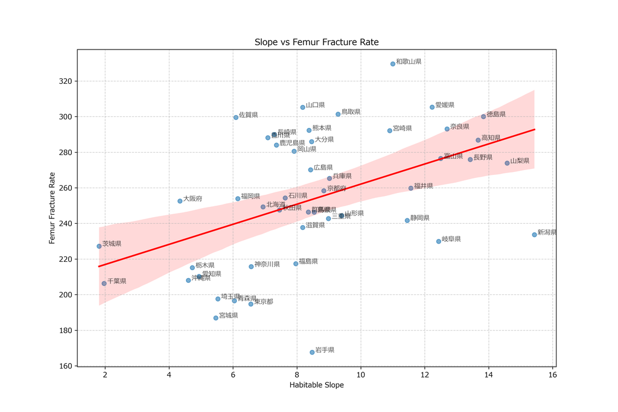

## 8.7 Figure 2

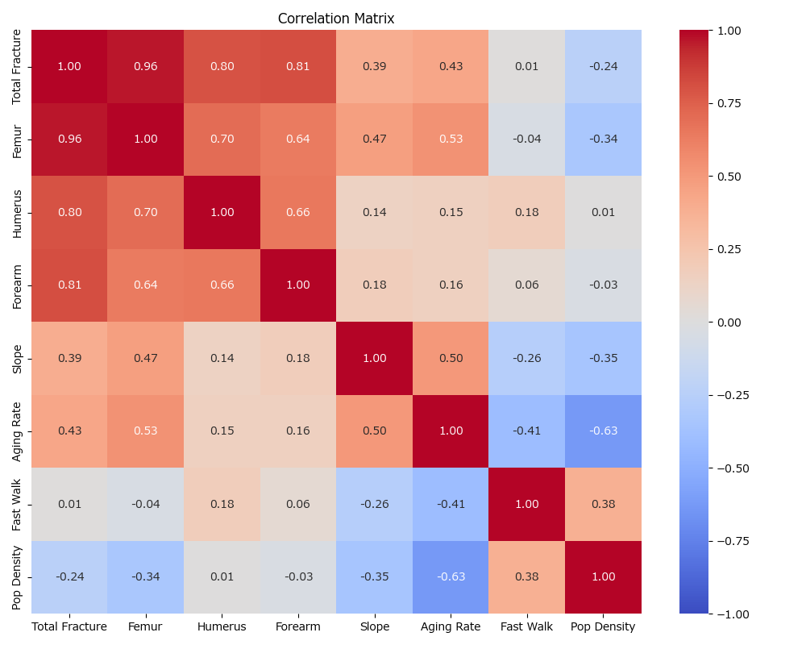

## 8.8 Figure 3

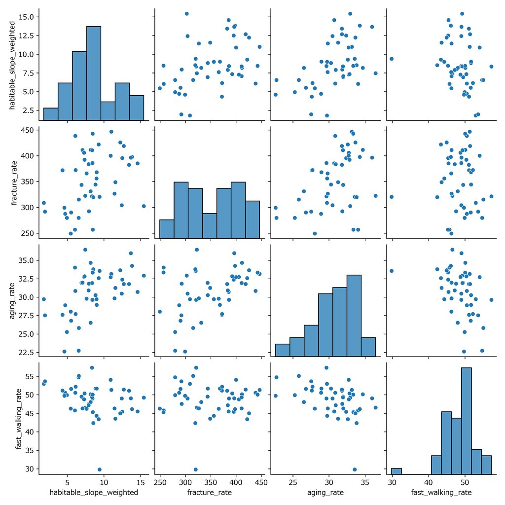

## 8.9 Figure 4

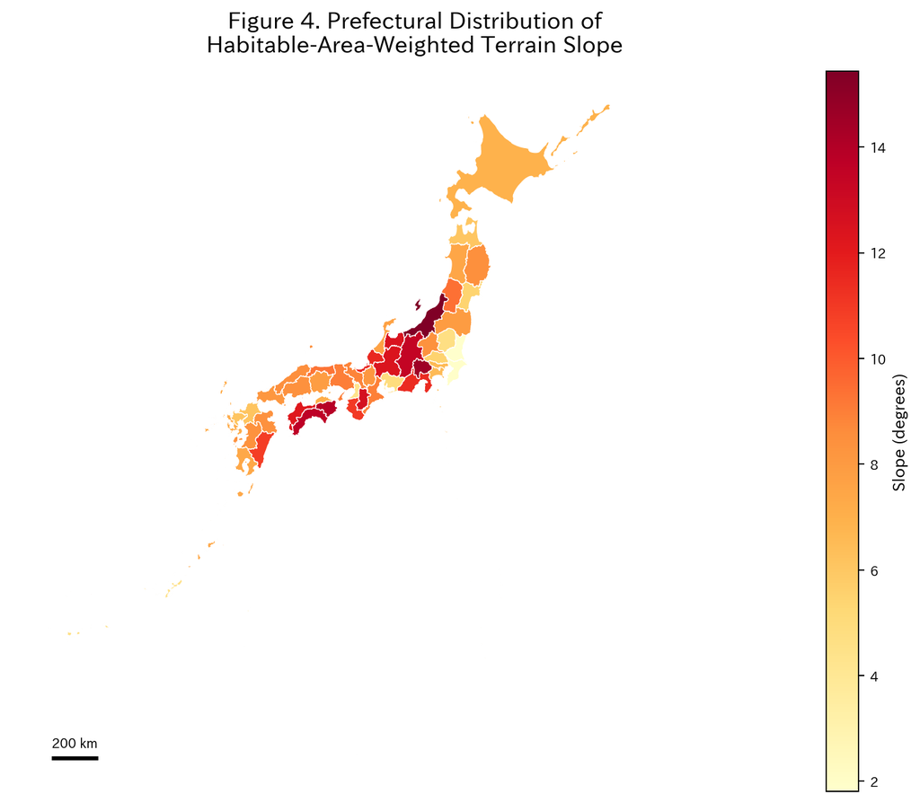

## 8.10 Figure 5

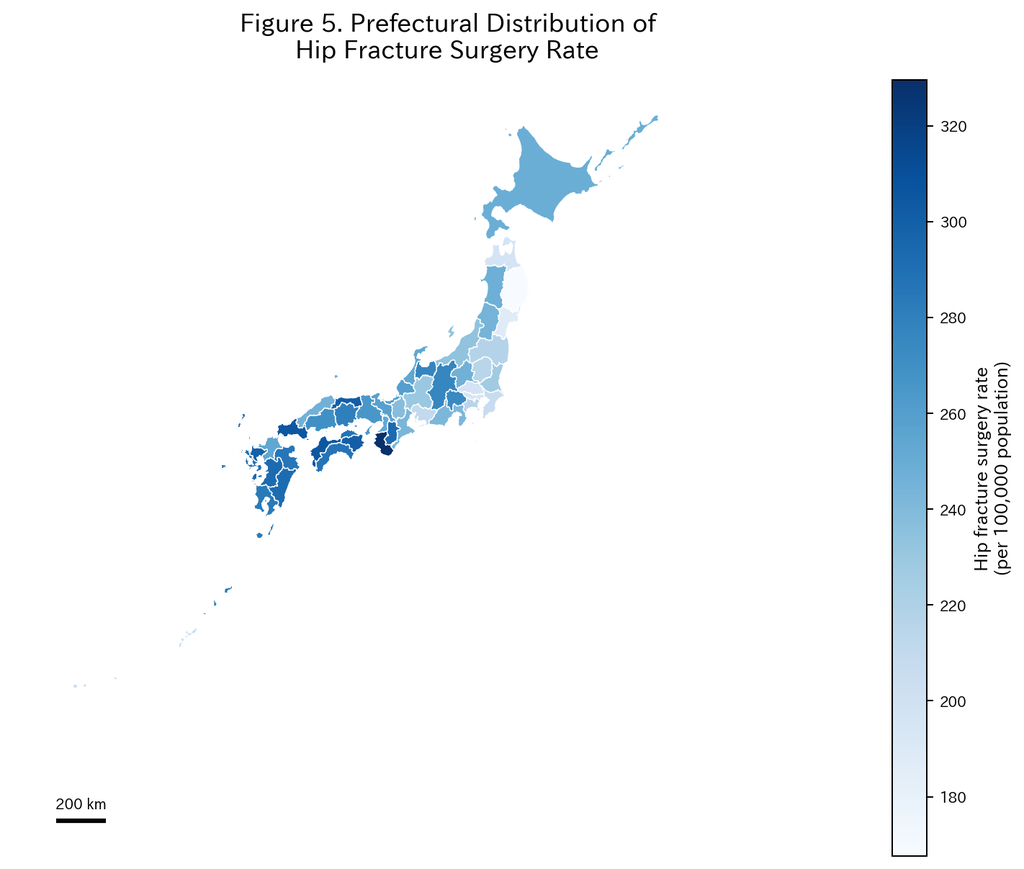

## 8.11 Figure 6

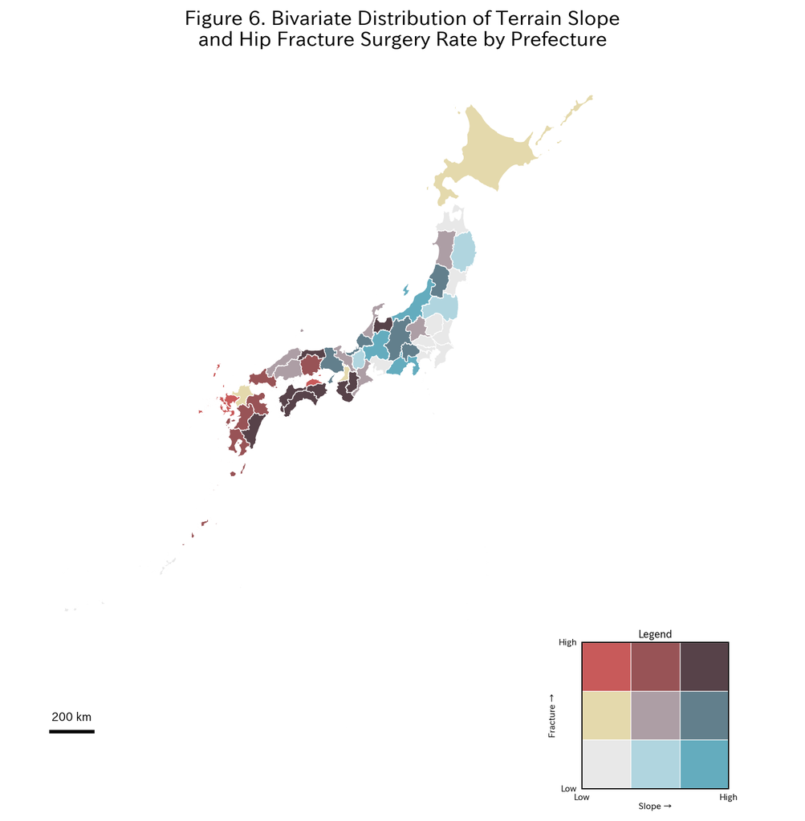